# Лабораторная работа №3

Настройка прав доступа

Ришард Когенгар

18 января 2026

# Цель работы

## Основная цель

Получение навыков настройки базовых и специальных прав доступа для групп пользователей в ОС типа Linux.

# Ход выполнения работы

## Подготовка каталогов

- Вход под `root`
- Созданы: `/data/main`, `/data/third`
- Проверены владелец/группа

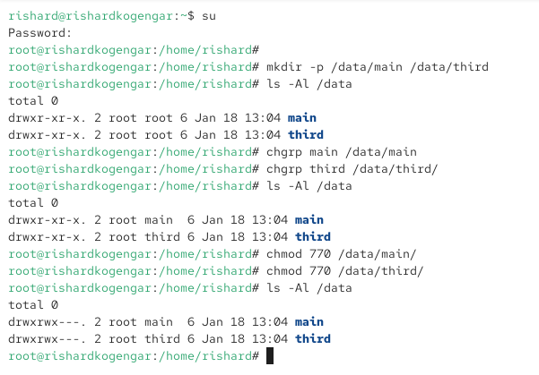

Подготовка каталогов

## Права 770 и проверка пользователя

- На каталоги выставлено `770`
- `bob` в группе **main** создаёт файл в `/data/main`
- Доступ в `/data/third` для `bob` запрещён

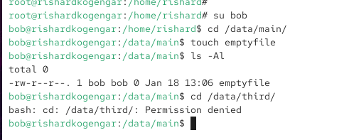

Проверка доступа bob

## Поведение без sticky bit

- `alice` создала файлы в `/data/main`
- `bob` смог удалить чужие файлы (запись в каталог разрешена группе)

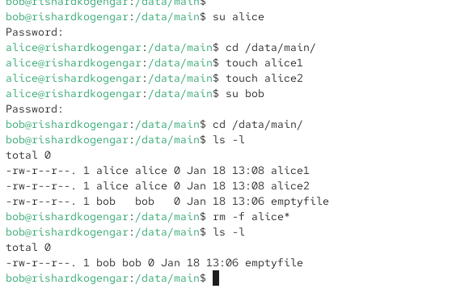

Удаление чужих файлов без sticky bit

## setgid + sticky bit на /data/main

- Включён **setgid**: новые файлы наследуют группу каталога
- Включён **sticky bit**: нельзя удалять чужие файлы

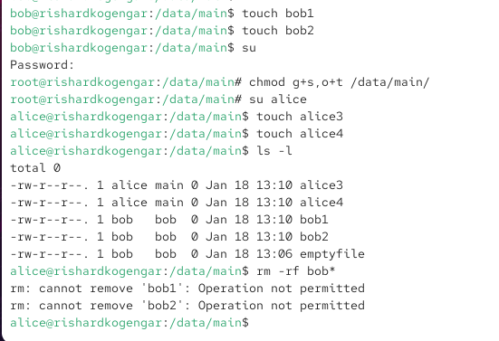

Эффект sticky bit

## ACL на каталоги

- Для `/data/main`: группе **third** выдано `r-x`
- Для `/data/third`: группе **main** выдано `r-x`
- Проверка через `getfacl`

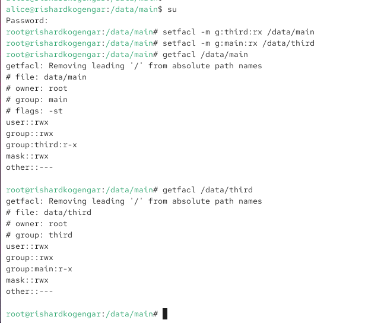

ACL на каталоги

## Проблема: ACL не наследуется

- Создан `newfile1`
- ACL каталога не перешёл на новый файл
- Нужны **default ACL**

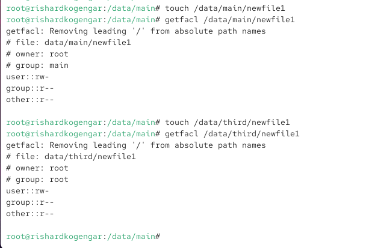

Отсутствие наследования

## Default ACL: наследование включено

- Заданы **default ACL** для каталогов
- Создан `newfile2`
- Новый файл получил нужные ACL автоматически

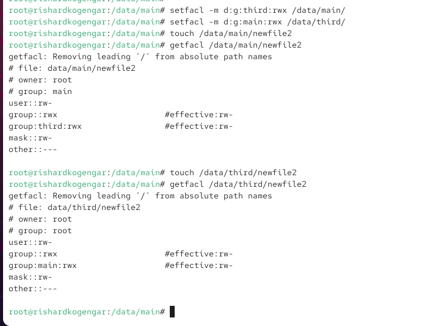

Наследование default ACL

## Проверка доступа пользователем third

- Вход под `carol` (группа **third**)
- Операции доступа/записи зависят от ACL файла и прав на каталог
- Удаление чужих файлов ограничено (sticky bit)

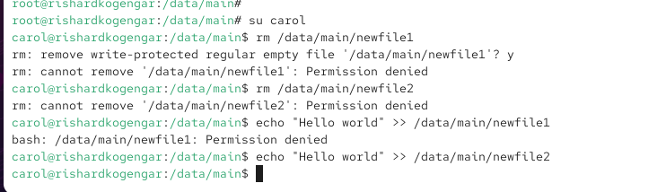

Проверка carol

# Выводы

## Итог

- Настроены базовые права `chmod` и разграничение по группам
- Проверены **setgid** (наследование группы) и **sticky bit** (защита от удаления чужих файлов)
- Настроены **ACL** и **default ACL** для наследования прав на новые файлы